[figure not shown]

# DA | BellaBeat | Google Capstone

This repository delves into the code that powered our exploration of women's health data for the Bellabeat project. Dive in and see how we analyzed the data!

Ready to Learn More?

- **Source Code:** Explore the code within this repository to understand how we analyzed Bellabeat's data.
- **Detailed Documentation:** For a deeper look at the project's goals, methodology, and results, check out our [documentation](https://github.com/JatinGagwani/BellaBeat-EDA).
- **Blog Post:** Get a quick overview of the project's key findings in our [blog post](https://www.jatingagwani.com/post/da-bellabeat-google-capstone).
- **Visit Our Site:** Interested in more data-driven health projects? Visit our website for similar endeavors: [https://www.jatingagwani.com/].
- **Questions?** Feel free to reach out!

**Urška Sršen** and **Sando Mur** founded **Bellabeat**, a company creating stylish health-focused smart products for women. Bellabeat empowers women by collecting data on activity, sleep, and stress, providing them with valuable insights into their health and habits. Since 2013, Bellabeat has grown rapidly, offering a range of products available through online retailers and their website. While Bellabeat utilizes traditional advertising, their primary focus is digital marketing. This includes Google Search optimization, active social media presence (Facebook, Instagram, Twitter), engaging video ads on Youtube, and targeted display ads on the Google Display Network.

**Bellabeat**, a leading women's health and wellness company, leverages technology to empower its users. Their stylish smart wearables track a range of health metrics, including:

- **Physical Activity**: Track steps, distance, and overall activity levels.
- **Sleep Patterns**: Gain insights into sleep quality, duration, and sleep stages.
- **Stress and Heart Rate**: Monitor stress levels and heart rate to understand overall well-being.

By collecting and analyzing this data, **Bellabeat** empowers women to gain valuable knowledge about their health and make informed lifestyle choices.

# ASK

## Project Objectives and Stakeholders

**Goal:** Grow Bellabeat's market share and position within the smart device industry.

### Objectives:

- Identify key user behavior trends through data analysis.
- Leverage these trends to refine and optimize Bellabeat's marketing strategies.

### Stakeholders:

- **Urška Sršen** (Co-founder & Chief Creative Officer): Oversees Bellabeat's creative direction and will be interested in user insights informing future product design and features.
- **Sando Mur** (Co-founder & Executive Team): With his expertise in mathematics, Mur will value data-driven insights for strategic decision making.
- **Bellabeat Marketing Analytics Team**: Responsible for utilizing data analysis to guide and improve marketing strategies. They will directly utilize the insights gleaned from this project.

## Data Preparation

### Source:

- Open-source "FitBit Fitness Tracker Data" from Kaggle.
- Data represents activity information from Fitbit users who consented to share their data.

### Data Considerations:

- **Reliability:** Due to the small sample size, findings may not be statistically significant and cannot be considered entirely reliable.
- **Originality:** The data is obtained from a third-party source (Kaggle).
- **Currency:** The data is not current, reflecting user activity patterns from 2016.
- **Citation:** As the data is from a third-party source, citation information is likely unavailable.

### Tools:

- Python for data cleaning, processing, transformation, and visualization.

## Leveraging Python Libraries:

This project will utilize Python's powerful data analysis libraries to uncover user behavior trends:

- **NumPy:** Provides the foundation for numerical computations and array manipulations, essential for handling user activity data.
- **Pandas:** Offers high-performance data structures (DataFrames) for efficient data organization, cleaning, and analysis.
- **Matplotlib:** A versatile library for creating various visualizations (charts, graphs) to explore trends and patterns in user activity.
- *(Optional) Scikit-learn:* If the data allows, this library might be used for more advanced analysis techniques like machine learning to uncover deeper user behavior insights.

These libraries work together seamlessly to streamline data manipulation, analysis, and visualization, enabling us to extract meaningful insights from the user activity data.

```python
import pandas as pd
import numpy as np
import matplotlib.pyplot as plt
import seaborn as sns
```

```python
import pandas as pd

# Read each CSV file
minutes_intensities_df = pd.read_csv("minuteIntensitiesNarrow_merged.csv", delimiter='\t')
minutes_mets_df = pd.read_csv("minuteMETsNarrow_merged.csv", delimiter='\t')
minute_sleep_df = pd.read_csv("minuteSleep_merged.csv", delimiter='\t')
minute_steps_df = pd.read_csv("minuteStepsNarrow_merged.csv")
weight_log_df = pd.read_csv("weightLogInfo_merged.csv")

# Export each DataFrame to separate CSV files
minutes_intensities_df.to_csv("minutesIntensitiesNarrow_merged_cleaned.csv", index=False)
minutes_mets_df.to_csv("minutesMETsNarrow_merged_cleaned.csv", index=False)
minute_sleep_df.to_csv("minuteSleep_merged_cleaned.csv", index=False)
minute_steps_df.to_csv("minuteStepsNarrow_merged_cleaned.csv", index=False)
weight_log_df.to_csv("weightLogInfo_merged_cleaned.csv", index=False)
```

```python
import pandas as pd

# Read the exported CSV files
cleaned_intensities_df = pd.read_csv("minutesIntensitiesNarrow_merged_cleaned.csv")
cleaned_mets_df = pd.read_csv("minutesMETsNarrow_merged_cleaned.csv")
cleaned_sleep_df = pd.read_csv("minuteSleep_merged_cleaned.csv")
cleaned_steps_df = pd.read_csv("minuteStepsNarrow_merged_cleaned.csv")
cleaned_weight_df = pd.read_csv("weightLogInfo_merged_cleaned.csv")

# Compare the first few rows of each cleaned DataFrame with the original ones
print("Original Intensities DataFrame:")
print(minutes_intensities_df.head())
print("\nCleaned Intensities DataFrame:")
print(cleaned_intensities_df.head())

# Similarly, compare and print other DataFrames as needed...
```

```
Original Intensities DataFrame:
          Id,ActivityMinute,Intensity
0  1503960366,4/12/2016 12:00:00 AM,0
1  1503960366,4/12/2016 12:01:00 AM,0
2  1503960366,4/12/2016 12:02:00 AM,0
3  1503960366,4/12/2016 12:03:00 AM,0
4  1503960366,4/12/2016 12:04:00 AM,0

Cleaned Intensities DataFrame:
          Id,ActivityMinute,Intensity
0  1503960366,4/12/2016 12:00:00 AM,0
1  1503960366,4/12/2016 12:01:00 AM,0
2  1503960366,4/12/2016 12:02:00 AM,0
3  1503960366,4/12/2016 12:03:00 AM,0
4  1503960366,4/12/2016 12:04:00 AM,0
```

```python
# Load the cleaned CSV files into pandas DataFrames
minutes_intensities_df = pd.read_csv("minutesIntensitiesNarrow_merged_cleaned.csv")
minutes_mets_df = pd.read_csv("minutesMETsNarrow_merged_cleaned.csv")
minute_sleep_df = pd.read_csv("minuteSleep_merged_cleaned.csv")
minute_steps_df = pd.read_csv("minuteStepsNarrow_merged_cleaned.csv")
weight_log_df = pd.read_csv("weightLogInfo_merged_cleaned.csv")
```

```python
# Display structure and content of each DataFrame
print("Minutes Intensities Data:")
print(minutes_intensities_df.info())
print(minutes_intensities_df.head())

print("\nMinutes METs Data:")
print(minutes_mets_df.info())
print(minutes_mets_df.head())

print("\nMinute Sleep Data:")
print(minute_sleep_df.info())
print(minute_sleep_df.head())

print("\nMinute Steps Data:")
print(minute_steps_df.info())
print(minute_steps_df.head())

print("\nWeight Log Data:")
print(weight_log_df.info())
print(weight_log_df.head())
```

```
Minutes Intensities Data:
<class 'pandas.core.frame.DataFrame'>
RangeIndex: 1325580 entries, 0 to 1325579
Data columns (total 1 columns):
 #   Column                       Non-Null Count    Dtype
---  ------                       --------------    -----
 0   Id,ActivityMinute,Intensity  1325580 non-null  object
dtypes: object(1)
memory usage: 10.1+ MB
None
          Id,ActivityMinute,Intensity
0  1503960366,4/12/2016 12:00:00 AM,0
1  1503960366,4/12/2016 12:01:00 AM,0
2  1503960366,4/12/2016 12:02:00 AM,0
3  1503960366,4/12/2016 12:03:00 AM,0
4  1503960366,4/12/2016 12:04:00 AM,0

Minutes METs Data:
<class 'pandas.core.frame.DataFrame'>
RangeIndex: 1325580 entries, 0 to 1325579
Data columns (total 1 columns):
 #   Column                  Non-Null Count    Dtype
---  ------                  --------------    -----
 0   Id,ActivityMinute,METs  1325580 non-null  object
dtypes: object(1)
memory usage: 10.1+ MB
None
                Id,ActivityMinute,METs
0  1503960366,4/12/2016 12:00:00 AM,10
1  1503960366,4/12/2016 12:01:00 AM,10
2  1503960366,4/12/2016 12:02:00 AM,10
3  1503960366,4/12/2016 12:03:00 AM,10
4  1503960366,4/12/2016 12:04:00 AM,10

Minute Sleep Data:
<class 'pandas.core.frame.DataFrame'>
RangeIndex: 188521 entries, 0 to 188520
Data columns (total 1 columns):
 #   Column               Non-Null Count   Dtype
---  ------               --------------   -----
```

[output cut: 45 more lines]

```
memory usage: 3.9+ KB
None
           Id                   Date    WeightKg  WeightPounds   Fat  \
0  1503960366   5/2/2016 11:59:59 PM   52.599998    115.963147  22.0
1  1503960366   5/3/2016 11:59:59 PM   52.599998    115.963147   NaN
2  1927972279   4/13/2016 1:08:52 AM  133.500000    294.317120   NaN
3  2873212765  4/21/2016 11:59:59 PM   56.700001    125.002104   NaN
4  2873212765  5/12/2016 11:59:59 PM   57.299999    126.324875   NaN

         BMI  IsManualReport          LogId
0  22.650000            True  1462233599000
1  22.650000            True  1462319999000
2  47.540001           False  1460509732000
3  21.450001            True  1461283199000
4  21.690001            True  1463097599000
```

```python
# Data Type Conversion
minutes_intensities_df['ActivityMinute'] = pd.to_datetime(minutes_intensities_df['Id,ActivityMinute,Intensity'].str.split(',').str[1])
minutes_mets_df['ActivityMinute'] = pd.to_datetime(minutes_mets_df['Id,ActivityMinute,METs'].str.split(',').str[1])
minute_sleep_df[['Id', 'ActivityMinute', 'Value', 'LogId']] = minute_sleep_df['Id,date,value,logId'].str.split(',', expand=True)
minute_sleep_df['ActivityMinute'] = pd.to_datetime(minute_sleep_df['ActivityMinute'])
weight_log_df['Date'] = pd.to_datetime(weight_log_df['Date'])

# Splitting Columns
minutes_intensities_df[['Id', 'ActivityMinute', 'Intensity']] = minutes_intensities_df['Id,ActivityMinute,Intensity'].str.split(',', expand=True)
minutes_mets_df[['Id', 'ActivityMinute', 'METs']] = minutes_mets_df['Id,ActivityMinute,METs'].str.split(',', expand=True)

# Handling Missing Values
weight_log_df['Fat'].fillna(weight_log_df['Fat'].mean(), inplace=True)
```

```python
# Summary Statistics
# Minutes Intensities Data
print("Summary Statistics for Minutes Intensities Data:")
print(minutes_intensities_df.describe())

# Minutes METs Data
print("\nSummary Statistics for Minutes METs Data:")
print(minutes_mets_df.describe())

# Minute Sleep Data
print("\nSummary Statistics for Minute Sleep Data:")
print(minute_sleep_df.describe())

# Minute Steps Data
print("\nSummary Statistics for Minute Steps Data:")
print(minute_steps_df.describe())

# Weight Log Data
print("\nSummary Statistics for Weight Log Data:")
print(weight_log_df.describe())
```

```
Summary Statistics for Minutes Intensities Data:
               Id,ActivityMinute,Intensity         ActivityMinute          Id  \
count                              1325580                1325580     1325580
unique                             1325580                  44160          33
top     1503960366,4/12/2016 12:00:00 AM,0  4/12/2016 12:00:00 AM  1927972279
freq                                     1                     33       44160

       Intensity
count    1325580
unique         4
top            0
freq     1112102

Summary Statistics for Minutes METs Data:
                     Id,ActivityMinute,METs         ActivityMinute  \
count                               1325580                1325580
unique                              1325580                  44160
top     1503960366,4/12/2016 12:00:00 AM,10  4/12/2016 12:00:00 AM
freq                                      1                     33

                Id     METs
count      1325580  1325580
unique          33      136
top     1927972279       10
freq         44160   879413

Summary Statistics for Minute Sleep Data:
                                  Id,date,value,logId          Id  \
count                                          188521      188521
unique                                         187978          24
top     4702921684,5/7/2016 12:12:00 AM,1,11573168523  5553957443
freq                                                2       15682
first                                             NaN         NaN
last                                              NaN         NaN

             ActivityMinute   Value        LogId
count                188521  188521       188521
unique                49773       3          459
top     2016-04-30 04:47:00       1  11573168523
freq                     13  172480         1086
```

[output cut: 19 more lines]

```
min    1.503960e+09   52.599998    115.963147  22.000000  21.450001
25%    6.962181e+09   61.400002    135.363832  23.500000  23.959999
50%    6.962181e+09   62.500000    137.788914  23.500000  24.389999
75%    8.877689e+09   85.049999    187.503152  23.500000  25.559999
max    8.877689e+09  133.500000    294.317120  25.000000  47.540001

              LogId
count  6.700000e+01
mean   1.461772e+12
std    7.829948e+08
min    1.460444e+12
25%    1.461079e+12
50%    1.461802e+12
75%    1.462375e+12
max    1.463098e+12
```

```
C:\Users\Jatin Gagwani\AppData\Local\Temp\ipykernel_6932\1853948837.py:12: FutureWarning: Treating datetime data as categorical rather than numeric in `.describe` is deprecated and will be removed in a future version of pandas. Specify `datetime_is_numeric=True` to silence this warning and adopt the…
  print(minute_sleep_df.describe())
```

```python
# Calculate correlation coefficients for Minutes Intensities Data
correlation_intensities = minutes_intensities_df.corr()

# Calculate correlation coefficients for Minutes METs Data
correlation_mets = minutes_mets_df.corr()

# Calculate correlation coefficients for Minute Sleep Data
correlation_sleep = minute_sleep_df.corr()

# Calculate correlation coefficients for Minute Steps Data
correlation_steps = minute_steps_df.corr()

# Calculate correlation coefficients for Weight Log Data
correlation_weight_log = weight_log_df.corr()

# Display correlation matrices
print("Correlation Matrix for Minutes Intensities Data:")
print(correlation_intensities)
print("\nCorrelation Matrix for Minutes METs Data:")
print(correlation_mets)
print("\nCorrelation Matrix for Minute Sleep Data:")
print(correlation_sleep)
print("\nCorrelation Matrix for Minute Steps Data:")
print(correlation_steps)
print("\nCorrelation Matrix for Weight Log Data:")
print(correlation_weight_log)
```

```
Correlation Matrix for Minutes Intensities Data:
Empty DataFrame
Columns: []
Index: []

Correlation Matrix for Minutes METs Data:
Empty DataFrame
Columns: []
Index: []

Correlation Matrix for Minute Sleep Data:
Empty DataFrame
Columns: []
Index: []

Correlation Matrix for Minute Steps Data:
             Id     Steps
Id     1.000000  0.034785
Steps  0.034785  1.000000

Correlation Matrix for Weight Log Data:
                      Id  WeightKg  WeightPounds       Fat       BMI  \
Id              1.000000  0.351346      0.351346  0.125661 -0.206405
WeightKg        0.351346  1.000000      1.000000  0.123777  0.735684
WeightPounds    0.351346  1.000000      1.000000  0.123777  0.735684
Fat             0.125661  0.123777      0.123777  1.000000  0.136222
BMI            -0.206405  0.735684      0.735684  0.136222  1.000000
IsManualReport -0.606458 -0.874964     -0.874964  0.000000 -0.326147
LogId          -0.060964 -0.225114     -0.225114 -0.144065 -0.235677

                IsManualReport     LogId
Id                   -0.606458 -0.060964
WeightKg             -0.874964 -0.225114
WeightPounds         -0.874964 -0.225114
Fat                   0.000000 -0.144065
BMI                  -0.326147 -0.235677
IsManualReport        1.000000  0.143830
LogId                 0.143830  1.000000
```

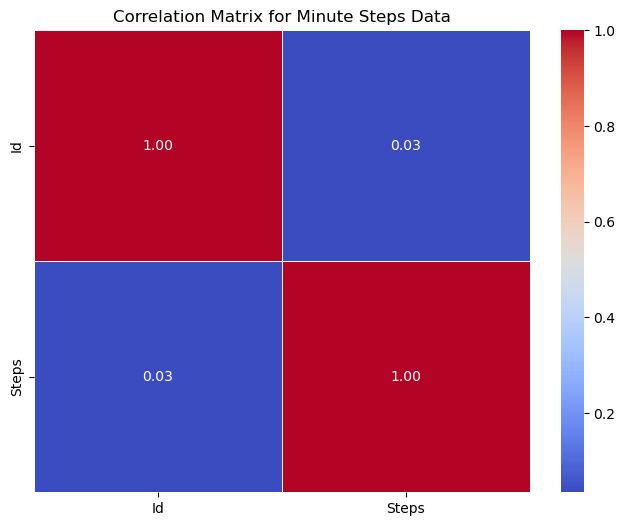

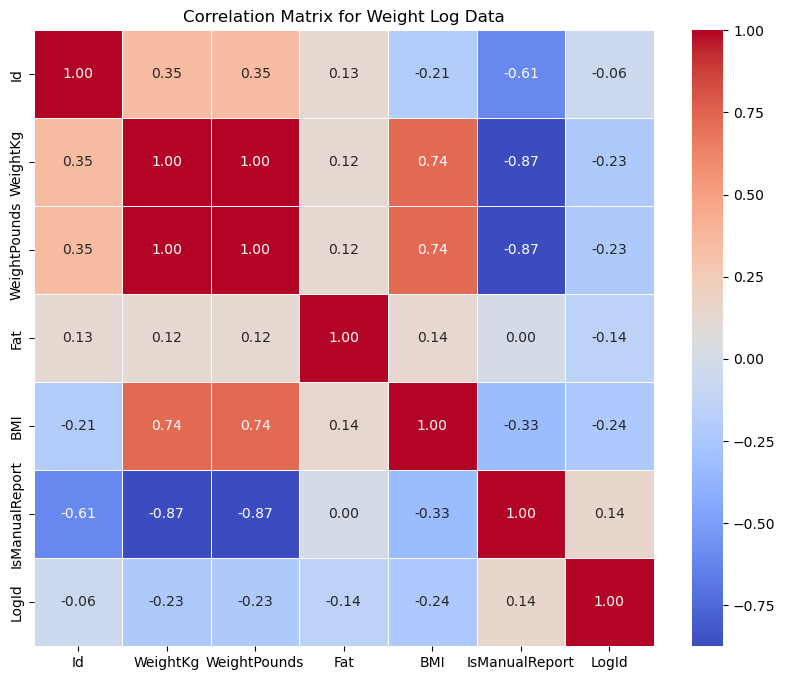

```python
import seaborn as sns
import matplotlib.pyplot as plt

# Correlation matrix for Minute Steps Data
plt.figure(figsize=(8, 6))
sns.heatmap(minute_steps_df.corr(), annot=True, cmap='coolwarm', fmt=".2f", linewidths=0.5)
plt.title('Correlation Matrix for Minute Steps Data')
plt.show()

# Correlation matrix for Weight Log Data
plt.figure(figsize=(10, 8))
sns.heatmap(weight_log_df.corr(), annot=True, cmap='coolwarm', fmt=".2f", linewidths=0.5)
plt.title('Correlation Matrix for Weight Log Data')
plt.show()
```

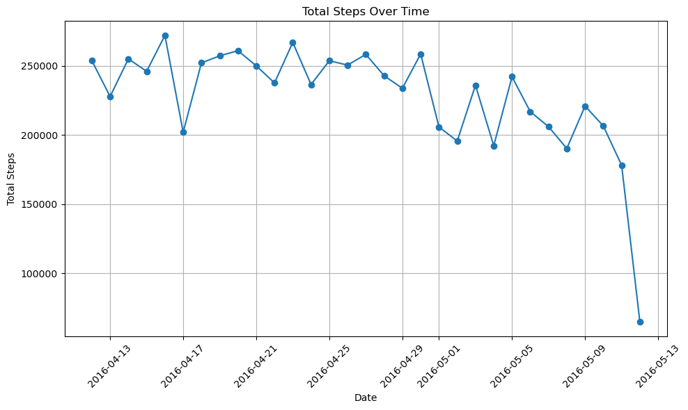

```python
import pandas as pd
import matplotlib.pyplot as plt

# Load the Minute Steps Data into a DataFrame
minute_steps_df = pd.read_csv("minuteStepsNarrow_merged_cleaned.csv")

# Convert 'ActivityMinute' to datetime
minute_steps_df['ActivityMinute'] = pd.to_datetime(minute_steps_df['ActivityMinute'])

# Aggregate steps data to calculate total steps per day
steps_per_day = minute_steps_df.groupby(minute_steps_df['ActivityMinute'].dt.date)['Steps'].sum()

# Create a line plot to visualize total steps over time
plt.figure(figsize=(10, 6))
plt.plot(steps_per_day.index, steps_per_day.values, marker='o', linestyle='-')
plt.title('Total Steps Over Time')
plt.xlabel('Date')
plt.ylabel('Total Steps')
plt.xticks(rotation=45)
plt.grid(True)
plt.tight_layout()
plt.show()
```